# Random Effects (ELMR Chapter 10)

Biostat 200C

Author

Dr. Jin Zhou @ UCLA

Published

May 13, 2026

Display system information and load `tidyverse` and `faraway` packages

```r
library(tidyverse)
library(faraway)
```

## 1 Introduction

- The `pulp` data set contains data from an experiment to test the paper brightness depending on a shift operator.

```r
pulp <- as_tibble(pulp) %>%
  print(n = Inf)
```

```
# A tibble: 20 × 2
   bright operator
    <dbl> <fct>
 1   59.8 a
 2   60   a
 3   60.8 a
 4   60.8 a
 5   59.8 a
 6   59.8 b
 7   60.2 b
 8   60.4 b
 9   59.9 b
10   60   b
11   60.7 c
12   60.7 c
13   60.5 c
14   60.9 c
15   60.3 c
16   61   d
17   60.8 d
18   60.6 d
19   60.5 d
20   60.5 d
```

Graphical summary:

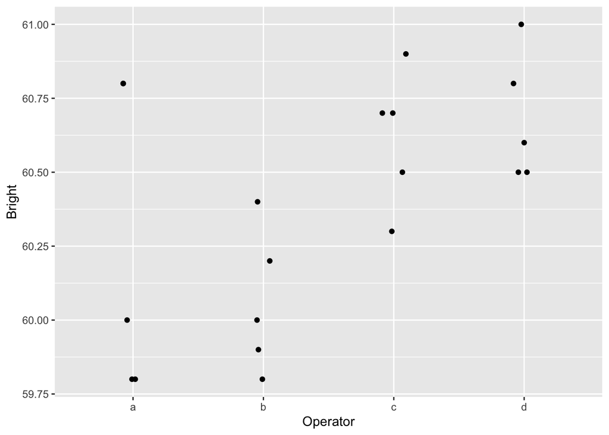

```r
pulp %>%
  ggplot(mapping = aes(x = operator, y = bright)) +
  geom_jitter(width=0.1, height=0.0) +
  labs(x = "Operator", y = "Bright")
```

- Research question is whether there is any difference in the paper brightness produced by different shift operators.
- We can answer the question using the classical ANOVA (analysis of variance)
  $$y_{ij} = \mu + \alpha_i + \epsilon_{ij}, \quad i = 1,\ldots,4, j = 1,\ldots,5,$$
  where $\epsilon_{ij}$ are assumed to be iid $N(0,\sigma^2)$.

```r
options(contrasts = c("contr.sum", "contr.poly"))
lmod <- lm(bright ~ operator, data = pulp)
summary(lmod)
```

```
Call:
lm(formula = bright ~ operator, data = pulp)

Residuals:
   Min     1Q Median     3Q    Max
-0.440 -0.195 -0.070  0.175  0.560

Coefficients:
            Estimate Std. Error t value Pr(>|t|)
(Intercept) 60.40000    0.07289 828.681   <2e-16 ***
operator1   -0.16000    0.12624  -1.267    0.223
operator2   -0.34000    0.12624  -2.693    0.016 *
operator3    0.22000    0.12624   1.743    0.101
---
Signif. codes:  0 '***' 0.001 '**' 0.01 '*' 0.05 '.' 0.1 ' ' 1

Residual standard error: 0.326 on 16 degrees of freedom
Multiple R-squared:  0.4408,    Adjusted R-squared:  0.3359
F-statistic: 4.204 on 3 and 16 DF,  p-value: 0.02261
```

The contrast `contr.sum` forces the coefficients for 4 operators sum to 0 (when using the dummy/one-hot coding). So the coeffiicient for the 4th operator is 0.28.

```r
model.matrix(lmod)
```

```
   (Intercept) operator1 operator2 operator3
1            1         1         0         0
2            1         1         0         0
3            1         1         0         0
4            1         1         0         0
5            1         1         0         0
6            1         0         1         0
7            1         0         1         0
8            1         0         1         0
9            1         0         1         0
10           1         0         1         0
11           1         0         0         1
12           1         0         0         1
13           1         0         0         1
14           1         0         0         1
15           1         0         0         1
16           1        -1        -1        -1
17           1        -1        -1        -1
18           1        -1        -1        -1
19           1        -1        -1        -1
20           1        -1        -1        -1
attr(,"assign")
[1] 0 1 1 1
attr(,"contrasts")
attr(,"contrasts")$operator
[1] "contr.sum"
```

The factor `operator` is significant with p-value 0.023.

```r
anova(lmod, test = "F")
```

```
Analysis of Variance Table

Response: bright
          Df Sum Sq Mean Sq F value  Pr(>F)
operator   3   1.34 0.44667  4.2039 0.02261 *
Residuals 16   1.70 0.10625
---
Signif. codes:  0 '***' 0.001 '**' 0.01 '*' 0.05 '.' 0.1 ' ' 1
```

- The hypothesis being tested in the ANOVA is *are these four operators same* in terms of the paper brightness they produce. This is called a **fixed effects model** because the effects $\alpha_i$ are assumed to be fixed.
- Suppose we are interested in the research question *are the population of operators all same* based on this data set? We will arrive a random effects model
  $$y_{ij} = \mu + \alpha_i + \epsilon_{ij}, \quad i = 1,\ldots,4, j = 1,\ldots,5,$$
  where we assume
  - $\alpha_i$ are iid from $N(0, \sigma_{\alpha}^2)$,
  - $\epsilon_{ij}$ are iid $N(0,\sigma_{\epsilon}^2)$, and
  - $\alpha_i$ and $\epsilon_{ij}$ are jointly independent.

  This is called a **random effects model** because now the effects $\alpha_i$ are assumed to be random. The parameters in this random effects model are $\mu$, $\sigma_\alpha^2$, and $\sigma_\epsilon^2$. The latter two are also called the variance component parameters. To test the research hypothesis, we would test $H_0: \sigma_\alpha^2=0$.
- Differences between a fixed effects model and a random effects model.
  1. the interpretation is different,
  2. random effects model can be more parsimonious (less parameters) than the corresponding fixed effects model,
  3. observations in random effects model are correlated.
- In this chapter, we study estimation and inference for mixed effects models.

## 2 Mixed effects model

- Traditionally, linear models can be divided into three categories:
  1. Fixed effects model: $\mathbf{y} = \mathbf{X} \boldsymbol{\beta} + \boldsymbol{\epsilon}$, where $\boldsymbol{\beta}$ is fixed.
  2. Random effects model: $\mathbf{y} = \mathbf{Z} \boldsymbol{\gamma} + \boldsymbol{\epsilon}$, where $\boldsymbol{\gamma}$ is random.
  3. Mixed effects model or mixed model: $\mathbf{y} = \mathbf{X} \boldsymbol{\beta} + \mathbf{Z} \boldsymbol{\gamma} + \boldsymbol{\epsilon}$, where $\boldsymbol{\beta}$ is fixed and $\boldsymbol{\gamma}$ is random.
- In a mixed effects model
  $$\begin{eqnarray*}
  \mathbf{y} = \mathbf{X} \boldsymbol{\beta} + \mathbf{Z} \boldsymbol{\gamma} + \boldsymbol{\epsilon}
  \end{eqnarray*}$$
  where
  - $\mathbf{X} \in \mathbb{R}^{n \times p}$ is a design matrix for fixed effects $\boldsymbol{\beta} \in \mathbb{R}^p$,
  - $\mathbf{Z} \in \mathbb{R}^{n \times q}$ is a design matrix for random effects $\boldsymbol{\gamma} \in \mathbb{R}^q$,
  - The most common assumption is $\boldsymbol{\epsilon} \sim N(\mathbf{0}_n, \sigma^2 \mathbf{I})$, $\boldsymbol{\gamma} \sim N(\mathbf{0}_q, \boldsymbol{\Sigma})$, and $\boldsymbol{\epsilon}$ is independent of $\boldsymbol{\gamma}$.
- Primary goal of the mixed model (aka variance components model) is to
  - estimation and testing of the fixed effects $\boldsymbol{\beta}$,
  - estimation and testing of the variance component parameters, and
  - prediction.

## 3 Example: one-way ANOVA

- For the one-way ANOVA random effects model with $a$ levels and $n_i$ observations in level $i$,
  $$y_{ij} = \mu + \alpha_i + \epsilon_{ij}, \quad i=1,\ldots,a,$$
  we recognize it as a mixed effects model
  $$\begin{eqnarray*}
  \mathbf{y} = \mathbf{1}_{\sum_i n_i} \mu + \begin{pmatrix}
  \mathbf{1}_{n_1} & & \\
  & \vdots & \\
  & & \mathbf{1}_{n_a}
  \end{pmatrix} \boldsymbol{\gamma} + \boldsymbol{\epsilon},
  \end{eqnarray*}$$
  where $\boldsymbol{\gamma} = (\alpha_1, \ldots, \alpha_a)^T \sim N(\mathbf{0}_a, \sigma_{\alpha}^2 \mathbf{I}_a)$ and $\boldsymbol{\epsilon} \sim N(\mathbf{0}_{\sum_i n_i}, \sigma_{\epsilon}^2 \mathbf{I})$ are independent. Note in $\mathbf{Z}$ we have one column for each level.
- How do we estimate parameters $\mu$, $\sigma_{\alpha}^2$, and $\sigma_{\epsilon}^2$?

## 4 Estimation

### 4.1 ANOVA estimator

- Consider the one-way ANOVA case. Assume we have a **balanced design**: $n_1 = \cdots = n_a = n$. That is each level has the same number of observations $n$. For example $n=5$ in the `pulp` example.
- Because $\mathbb{E} Y_{ij} = \mu$. So we can estimate $\mu$ by average of $y_{ij}$

```r
mean(pulp$bright)
```

```
[1] 60.4
```

- To estimate the variance component parameters $\sigma_a^2$ and $\sigma_\epsilon^2$, the familiar ANOVA table gives the partition
  $$\begin{eqnarray*}
  \text{SST} &=& \text{SSE} + \text{SSA} \\
  \sum_{i=1}^a \sum_{j=1}^n (y_{ij} - \bar{y}_{\cdot \cdot})^2 &=& \sum_{i=1}^a \sum_{j=1}^n (y_{ij} - \bar{y}_{i \cdot})^2 + \sum_{i=1}^a \sum_{j=1}^n (\bar{y}_{i \cdot} - \bar{y}_{\cdot \cdot})^2.
  \end{eqnarray*}$$
  Now we have (show in **HW5**)
  $$\begin{eqnarray*}
  \mathbb{E} (\text{SSE}) &=& a(n-1) \sigma_{\epsilon}^2 \\
  \mathbb{E} (\text{SSA}) &=& (a-1)(n \sigma_{\alpha}^2 + \sigma_{\epsilon}^2),
  \end{eqnarray*}$$
  which can be solved to obtain estimators
  $$\begin{eqnarray*}
  \widehat{\sigma}_{\epsilon}^2 &=& \frac{\text{SSE}}{a(n-1)} = \text{MSE}, \\
  \widehat{\sigma}_{\alpha}^2 &=& \frac{\text{SSA}/(a-1) - \widehat{\sigma}_{\epsilon}^2}{n} = \frac{\text{MSA} - \text{MSE}}{n}.
  \end{eqnarray*}$$
- For the `pulp` data, the ANOVA table is

```r
(aovmod <- aov(bright ~ operator, data = pulp) %>%
  summary())
```

```
            Df Sum Sq Mean Sq F value Pr(>F)
operator     3   1.34  0.4467   4.204 0.0226 *
Residuals   16   1.70  0.1062
---
Signif. codes:  0 '***' 0.001 '**' 0.01 '*' 0.05 '.' 0.1 ' ' 1
```

```r
str(aovmod)
```

```
List of 1
 $ :Classes 'anova' and 'data.frame':   2 obs. of  5 variables:
  ..$ Df     : num [1:2] 3 16
  ..$ Sum Sq : num [1:2] 1.34 1.7
  ..$ Mean Sq: num [1:2] 0.447 0.106
  ..$ F value: num [1:2] 4.2 NA
  ..$ Pr(>F) : num [1:2] 0.0226 NA
 - attr(*, "class")= chr [1:2] "summary.aov" "listof"
```

We estimate $\sigma_{\alpha}^2$ by

```r
(aovmod[1][[1]][[3]][1] - aovmod[1][[1]][[3]][2]) / 5
```

```
[1] 0.06808333
```

and $\sigma_{\epsilon}^2$ by

```r
aovmod[1][[1]][[3]][2]
```

```
[1] 0.10625
```

- Drawbacks of ANOVA estimators.
  1. When MSA<MSE, we obtain negative $\widehat{\sigma}_{\alpha}^2$.
  2. Hard to generalize to unbalanced ANOVA or more complicated designs.

### 4.2 Maximum likelihood estimation (MLE)

- For the mixed effects model
  $$\begin{eqnarray*}
  \mathbf{y} = \mathbf{X} \boldsymbol{\beta} + \mathbf{Z} \boldsymbol{\gamma} + \boldsymbol{\epsilon},
  \end{eqnarray*}$$
  where $\boldsymbol{\epsilon} \sim N(\mathbf{0}_n, \sigma^2 \mathbf{I})$ and $\boldsymbol{\gamma} \sim N(\mathbf{0}_q, \boldsymbol{\Sigma})$ are independent of each other, we have
  $$\mathbf{Y} \sim N(\mathbf{X} \boldsymbol{\beta}, \mathbf{Z} \boldsymbol{\Sigma} \mathbf{Z}^T + \sigma^2 \mathbf{I}).$$
  So the likelihood is
  $$\frac{1}{(2\pi)^{n/2} \det(\mathbf{Z} \boldsymbol{\Sigma} \mathbf{Z}^T + \sigma^2 \mathbf{I})^{1/2}} e^{- \frac 12 (\mathbf{y} - \mathbf{X} \boldsymbol{\beta})^T (\mathbf{Z} \boldsymbol{\Sigma} \mathbf{Z}^T + \sigma^2 \mathbf{I})^{-1} (\mathbf{y} - \mathbf{X} \boldsymbol{\beta})}$$
  and the log-likelihood is
  $$\ell(\boldsymbol{\beta}, \boldsymbol{\Sigma}, \sigma^2) = - \frac n2 \log(2\pi) - \frac 12 \log \det (\mathbf{Z} \boldsymbol{\Sigma} \mathbf{Z}^T + \sigma^2 \mathbf{I}) - \frac 12 (\mathbf{y} - \mathbf{X} \boldsymbol{\beta})^T (\mathbf{Z} \boldsymbol{\Sigma} \mathbf{Z}^T + \sigma^2 \mathbf{I})^{-1} (\mathbf{y} - \mathbf{X} \boldsymbol{\beta}).$$
- We can maximize the log-likelihood function to obtain MLE.
- **Exercise (HW5)**: Derive the MLE for the balanced one-way ANOVA example.
- One drawback of MLE is that it produces biased estimate for the variance component parameters $\sigma^2$ and $\boldsymbol{\Sigma}$. E.g., in the linear regression case (fixed effects model), MLE for $\sigma^2$ is
  $$\widehat{\sigma}_{\text{MLE}}^2 = \frac{\text{RSS}}{n},$$
  where an unbiased estimator is
  $$\widehat{\sigma}^2 = \frac{\text{RSS}}{n-p},$$
  where $p$ is the number of parameters.
- Let’s find the MLE for the `pulp` data using `lme4` package. The syntax `(1 | operator)` instructs that the data is grouped by `operator` and the `1` indicates that random effect is constant within each group. The default method is REML so we set `REML = FALSE` to compute the MLE instead.

```r
library(lme4)

smod <- lmer(bright ~ 1 + (1 | operator), data = pulp, REML = FALSE)
summary(smod)
```

```
Linear mixed model fit by maximum likelihood  ['lmerMod']
Formula: bright ~ 1 + (1 | operator)
   Data: pulp

      AIC       BIC    logLik -2*log(L)  df.resid
     22.5      25.5      -8.3      16.5        17

Scaled residuals:
     Min       1Q   Median       3Q      Max
-1.50554 -0.78116 -0.06353  0.65850  1.56232

Random effects:
 Groups   Name        Variance Std.Dev.
 operator (Intercept) 0.04575  0.2139
 Residual             0.10625  0.3260
Number of obs: 20, groups:  operator, 4

Fixed effects:
            Estimate Std. Error t value
(Intercept)  60.4000     0.1294   466.7
```

### 4.3 Restricted MLE (REML)

- The restricted maximum likelihood (REML) method tries to reduce the bias in variance component estimates.
- Assume $\mathbf{X}$ has full column rank $p$. Let $\mathbf{K} \in \mathbb{R}^{n \times (n-p)}$ be an basis of the space ${\cal N}(\mathbf{X}^T)$, which is orthogonal to ${\cal C}(\mathbf{X})$. Then
  $$\mathbf{K}^T \mathbf{Y} \sim N(\mathbf{0}_{n-p}, \mathbf{K}^T (\mathbf{Z} \boldsymbol{\Sigma} \mathbf{Z}^T + \sigma^2 \mathbf{I}) \mathbf{K}).$$
  We estimate variance component parameters $(\sigma^2, \boldsymbol{\Sigma})$ by MLE using this transformed data $(\mathbf{K}^T \mathbf{y}, \mathbf{K}^T \mathbf{Z})$. Then we estimate fixed effects $\boldsymbol{\beta}$ using general least squares. It can be shown that the REML estimate does not depend on the choice of $\mathbf{K}$.
- Let’s find the REML for the `pulp` data using `lme4`.

```r
library(lme4)

mmod <- lmer(bright ~ 1 + (1 | operator), data = pulp, REML = TRUE)
summary(mmod)
```

```
Linear mixed model fit by REML ['lmerMod']
Formula: bright ~ 1 + (1 | operator)
   Data: pulp

REML criterion at convergence: 18.6

Scaled residuals:
    Min      1Q  Median      3Q     Max
-1.4666 -0.7595 -0.1244  0.6281  1.6012

Random effects:
 Groups   Name        Variance Std.Dev.
 operator (Intercept) 0.06808  0.2609
 Residual             0.10625  0.3260
Number of obs: 20, groups:  operator, 4

Fixed effects:
            Estimate Std. Error t value
(Intercept)  60.4000     0.1494   404.2
```

We found the REML estimate is exactly same as ANOVA estimate. **Exercise (HW5)**: show this.

## 5 Inference

### 5.1 LRT and adjusted F test for fixed effects

- If we compare two nested models that differ only in fixed effects, we can use the standard likelihood ratio test (LRT). Remember we have to use MLE (not REML) for LRT.
- F tests for fixed effects need to use adjusted degrees of freedom (Kenward-Roger adjusted F-test for REML), as implemented in the `pbkrtest` package.

### 5.2 Parametric bootstrap

- Testing the variance component parameters, e.g., $H_0:\sigma_{\alpha}^2=0$, can be hard because of the boundary condition (estimator has to be nonnegative). Conventional $\chi^2$ null distribution for LRT can be wrong. E.g., for the `pulp` data, LRT using the the conventional $\chi_1^2$ null distribution gives a non-significant p-value.

```r
nullmod <- lm(bright ~ 1, data = pulp)
(lrtstat <- as.numeric(2 * (logLik(smod, REML = FALSE) - logLik(nullmod))))
```

```
[1] 2.568371
```

```r
# fishy result using LRT
pchisq(lrtstat, 1, lower.tail = FALSE)
```

```
[1] 0.1090199
```

- The idea of parameteric bootstrap is we generate new $y$ from the fitted null model many times. For each simulation replicate, we calculate the LRT statistic. Then the p-value is estimated by the proportion of simulation replicates that generate LRT statistics larger than the observed one $2.5684$.

```r
B <- 1000
lrstat <- numeric(B)
set.seed(123) # for reproducibility
for (i in 1:B) {
  by <- unlist(simulate(nullmod))
  bnull <- lm(by ~ 1)
  #balt  <- refitML(smod, by)
  balt  <- suppressMessages(lmer(by ~ 1 + (1 | operator), pulp, REML = FALSE))
  lrstat[i] <- as.numeric(2 * (logLik(balt, REML = FALSE) - logLik(bnull)))
}
```

Then the bootstrap p-value is

```r
# parametric bootstrap p-value
(pval <- mean(lrstat > 2.5684))
```

```
[1] 0.019
```

with standard error

```r
sqrt(pval * (1 - pval) / B)
```

```
[1] 0.004317291
```

- Advantages of parametric boostrap:
  - It’s not restricted to MLE estimators. It applies to many other estimators.
  - It does not rely on the dubious asymptotic $\chi^2$ distribution.
  - It can be used to generate confidence intervals.
  - It applies to inference of both $\boldsymbol{\beta}$ and variance component parameters.
- Drawbacks of parametric bootstrap: computationally intensive.

### 5.3 Exact LRT and RLRT test

Another simulation based method is provided by the `RLRsim` package.

```r
library(RLRsim)

exactLRT(smod, nullmod)
```

```
    simulated finite sample distribution of LRT. (p-value based on 10000
    simulated values)

data:
LRT = 2.5684, p-value = 0.0241
```

```r
exactRLRT(mmod)
```

```
    simulated finite sample distribution of RLRT.

    (p-value based on 10000 simulated values)

data:
RLRT = 3.4701, p-value = 0.0224
```

## 6 Estimate random effects

- Consider the mixed effects model
  $$\begin{eqnarray*}
  \mathbf{y} = \mathbf{X} \boldsymbol{\beta} + \mathbf{Z} \boldsymbol{\gamma} + \boldsymbol{\epsilon},
  \end{eqnarray*}$$
  where $\boldsymbol{\epsilon} \sim N(\mathbf{0}_n, \sigma^2 \mathbf{I})$ and $\boldsymbol{\gamma} \sim N(\mathbf{0}_q, \boldsymbol{\Sigma})$ are independent of each other. The random effects $\boldsymbol{\gamma}$ are random variables. It does not make sense to estimate $\boldsymbol{\gamma}$.
- However, if we take the Bayesian point of view, we can estimate it by its posterior mean. We have a **likelihood**
  $$\mathbf{y} \mid \boldsymbol{\gamma} \sim N(\mathbf{X} \boldsymbol{\beta} + \mathbf{Z} \boldsymbol{\gamma}, \sigma^2 \mathbf{I}_n)$$
  and a **prior distribution**
  $$\boldsymbol{\gamma} \sim N(\mathbf{0}_q, \boldsymbol{\Sigma}).$$
  Then by the Bayes theorem, the **posterior distribution** is
  $$\begin{eqnarray*}
  f(\boldsymbol{\gamma} \mid \mathbf{y}) &=& \frac{f(\mathbf{y} \mid \boldsymbol{\gamma}) \times f(\boldsymbol{\gamma})}{f(\mathbf{y})} \\
  &=& ...
  \end{eqnarray*}$$
  is a multivariate normal with mean (show in **HW5**)
  $$\mathbb{E} (\boldsymbol{\gamma} \mid \mathbf{y}) = \boldsymbol{\Sigma} \mathbf{Z}^T (\mathbf{Z} \boldsymbol{\Sigma} \mathbf{Z}^T + \sigma^2 \mathbf{I})^{-1} (\mathbf{y} - \mathbf{X} \boldsymbol{\beta}).$$
- We can use this posterior mean to estimate random effects. For the `pulp` data, estimate of random effects is obtained by

```r
ranef(mmod)$operator
```

```
  (Intercept)
a  -0.1219403
b  -0.2591231
c   0.1676679
d   0.2133955
```

Compare these to the coefficients from fixed effects model:

```r
(cc <- model.tables(aov(bright ~ operator, data = pulp)))
```

```
Tables of effects

 operator
operator
    a     b     c     d
-0.16 -0.34  0.22  0.28
```

We found the estimated random effects are uniformly smaller than the fixed effects

```r
cc[[1]]$operator / ranef(mmod)$operator
```

```
  (Intercept)
a    1.312117
b    1.312117
c    1.312117
d    1.312117
```

That’s why Bayesian estimates are often called the shrinkage estimator. **Exercise:** prove this in HW5 for the balanced one-way ANOVA example.

## 7 Prediction

- For the observed levels (an operator we know), the **best linear unbiased predictors (BLUP)** is obtained by

```r
fixef(mmod) + ranef(mmod)$operator
```

```
  (Intercept)
a    60.27806
b    60.14088
c    60.56767
d    60.61340
```

or

```r
predict(mmod, newdata = data.frame(operator="a"))
```

```
       1
60.27806
```

- For a new operator, the best we can do is the intercept.

```r
predict(mmod, re.form = ~ 0)
```

```
   1    2    3    4    5    6    7    8    9   10   11   12   13   14   15   16
60.4 60.4 60.4 60.4 60.4 60.4 60.4 60.4 60.4 60.4 60.4 60.4 60.4 60.4 60.4 60.4
  17   18   19   20
60.4 60.4 60.4 60.4
```

## 8 Diagnostics

- Diagnostic plots for random effects usually use the residuals calculated using predicted random effects. These residuals are regarded as estimates of $\epsilon$.
- QQ-plot.

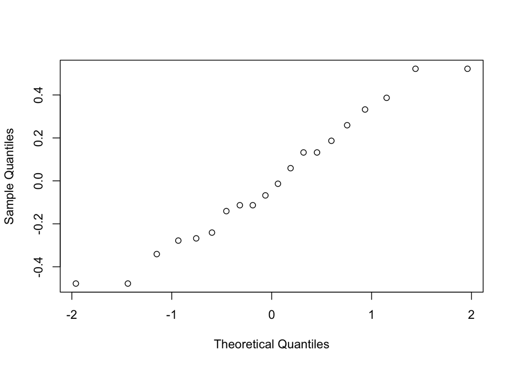

```r
qqnorm(residuals(mmod), main="")
```

- Residual vs fitted.

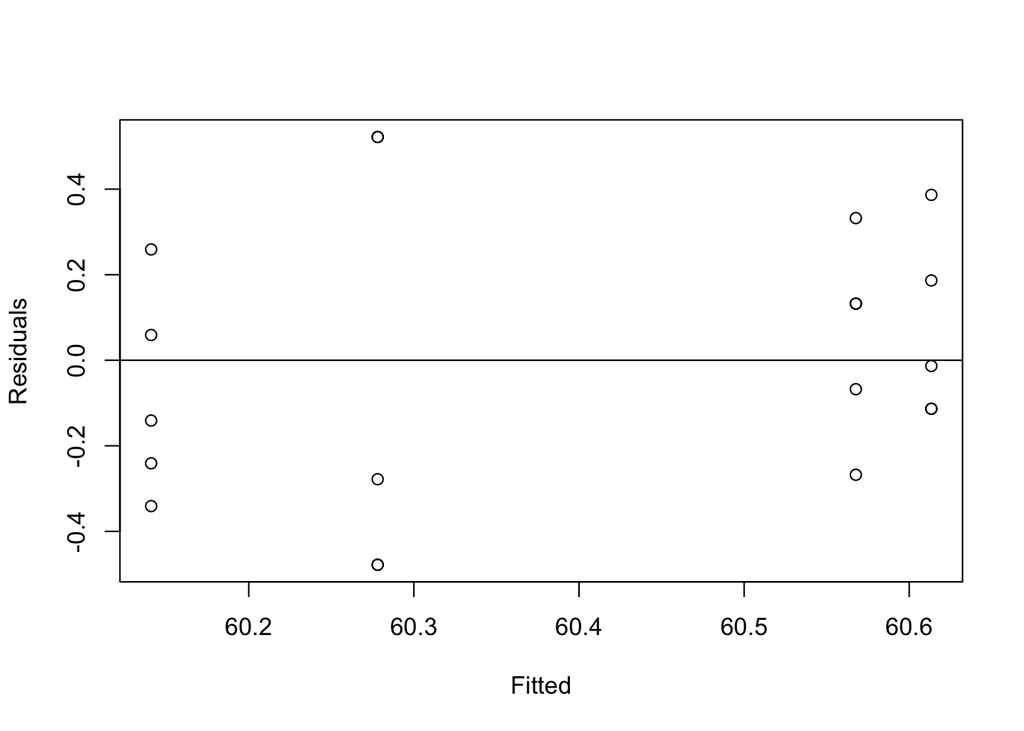

```r
plot(fitted(mmod), residuals(mmod), xlab = "Fitted", ylab = "Residuals")
abline(h=0)
```

## 9 Blocks as random effects

- In the `pulp` example, `operator` defines blocks.
- In the `penicillin` data set, we want to study how `yield` depends on the `treat` (proccess) and `blend` (corn steep liquor). It is natural to treat `treat` as fixed effects and `blend` as a blocking variable (random effects).

```r
penicillin
```

```
   treat  blend yield
1      A Blend1    89
2      B Blend1    88
3      C Blend1    97
4      D Blend1    94
5      A Blend2    84
6      B Blend2    77
7      C Blend2    92
8      D Blend2    79
9      A Blend3    81
10     B Blend3    87
11     C Blend3    87
12     D Blend3    85
13     A Blend4    87
14     B Blend4    92
15     C Blend4    89
16     D Blend4    84
17     A Blend5    79
18     B Blend5    81
19     C Blend5    80
20     D Blend5    88
```

- Graphical summary

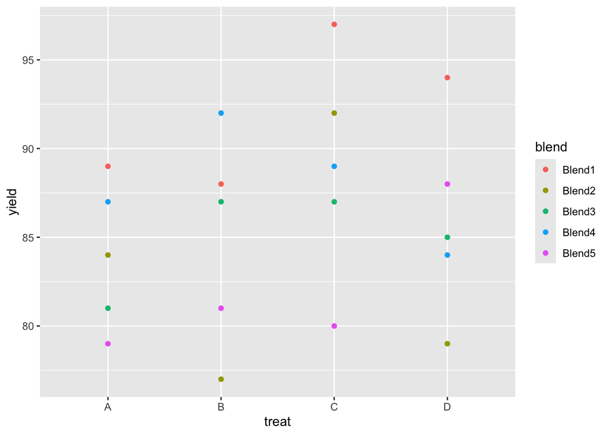

```r
penicillin %>%
  ggplot() +
  geom_point(mapping = aes(x = treat, y = yield, color = blend))
```

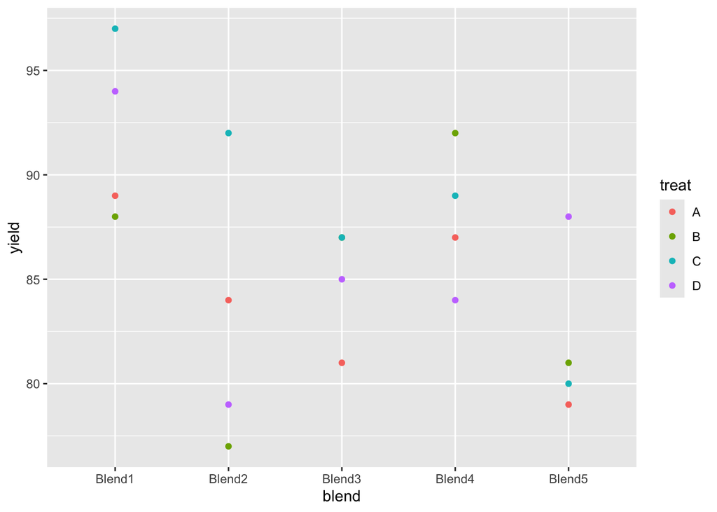

```r
penicillin %>%
  ggplot() +
  geom_point(mapping = aes(x = blend, y = yield, color = treat))
```

- Classical two-way ANOVA:

```r
op <- options(contrasts = c("contr.sum", "contr.poly"))
lmod <- aov(yield ~ blend + treat, data = penicillin)
summary(lmod)
```

```
            Df Sum Sq Mean Sq F value Pr(>F)
blend        4    264   66.00   3.504 0.0407 *
treat        3     70   23.33   1.239 0.3387
Residuals   12    226   18.83
---
Signif. codes:  0 '***' 0.001 '**' 0.01 '*' 0.05 '.' 0.1 ' ' 1
```

```r
coef(lmod)
```

```
(Intercept)      blend1      blend2      blend3      blend4      treat1
         86           6          -3          -1           2          -2
     treat2      treat3
         -1           3
```

- It is reasonable to treat `treat` as fixed effects and `blend` as random effects (draws from the population of blend).

```r
mmod <- lmer(yield ~ treat + (1 | blend), data = penicillin)
summary(mmod)
```

```
Linear mixed model fit by REML ['lmerMod']
Formula: yield ~ treat + (1 | blend)
   Data: penicillin

REML criterion at convergence: 106.6

Scaled residuals:
    Min      1Q  Median      3Q     Max
-1.4152 -0.5017 -0.1644  0.6830  1.2836

Random effects:
 Groups   Name        Variance Std.Dev.
 blend    (Intercept) 11.79    3.434
 Residual             18.83    4.340
Number of obs: 20, groups:  blend, 5

Fixed effects:
            Estimate Std. Error t value
(Intercept)   86.000      1.817  47.341
treat1        -2.000      1.681  -1.190
treat2        -1.000      1.681  -0.595
treat3         3.000      1.681   1.785

Correlation of Fixed Effects:
       (Intr) treat1 treat2
treat1  0.000
treat2  0.000 -0.333
treat3  0.000 -0.333 -0.333
```

```r
options(op)
```

Random effect estimates are shrunken version of fixed effect estimates.

```r
ranef(mmod)$blend
```

```
       (Intercept)
Blend1   4.2878788
Blend2  -2.1439394
Blend3  -0.7146465
Blend4   1.4292929
Blend5  -2.8585859
```

### 9.1 Test fixed effects

- Kenward-Roger adjusted F-tests for REML.

```r
library(pbkrtest)

amod_reml <- lmer(yield ~ treat + (1 | blend), data = penicillin, REML = TRUE)
nmod_reml <- lmer(yield ~ 1 + (1 | blend), data = penicillin, REML = TRUE)
KRmodcomp(amod_reml, nmod_reml)
```

```
large : yield ~ treat + (1 | blend)
small : yield ~ 1 + (1 | blend)
         stat     ndf     ddf F.scaling p.value
Ftest  1.2389  3.0000 12.0000         1  0.3387
```

- LRT using $\chi^2$ null distribution.

```r
amod_mle <- lmer(yield ~ treat + (1 | blend), data = penicillin, REML = FALSE)
nmod_mle <- lmer(yield ~ 1 + (1 | blend), data = penicillin, REML = FALSE)
as.numeric(2 * (logLik(amod_mle, REML = FALSE) - logLik(nmod_mle, REML = FALSE)))
```

```
[1] 4.047367
```

The $\chi_3^2$ approximation gives p-value

```r
pchisq(4.0474, 3, lower.tail = FALSE)
```

```
[1] 0.2563911
```

- Parametric bootstrap. Now we use parametric bootstrap to obtain a p-value for the LRT.

```r
set.seed(123)
B <- 1000
lrstat <- numeric(B)
for (i in 1:B) {
  ryield <- unlist(simulate(nmod_mle))
  nmodr <- suppressMessages(lmer(ryield ~ 1 + (1 | blend), data = penicillin, REML = FALSE))
  amodr <- suppressMessages(lmer(ryield ~ treat + (1 | blend), data = penicillin, REML = FALSE))
  lrstat[i] <- 2 * (logLik(amodr, REML = FALSE) - logLik(nmodr, REML = FALSE))
}
```

The bootstrap p-value is

```r
# p-value estimated by parametric bootstrap
(pval <- mean(lrstat > 4.0474))
```

```
[1] 0.352
```

with standard error

```r
sqrt(pval * (1 - pval) / B)
```

```
[1] 0.01510285
```

- The `pbkrtest` packages automate this parametric boostrap procedure (`PBtest`) along with LRT and other tests for fixed effects. LRT and parametric bootstrap results are similar to what we got. Note the F test here is the LRT divided by the degrees of freedom assumed to be F-distributed.

```r
library(pbkrtest)

set.seed(123)
PBmodcomp(amod_reml, nmod_reml) %>%
  summary()
```

```
Bootstrap test; time: 10.70 sec; samples: 1000; extremes: 353;
large : yield ~ treat + (1 | blend)
           stat     df    ddf p.value
LRT      4.0474 3.0000         0.2564
PBtest   4.0474                0.3536
Gamma    4.0474                0.3496
Bartlett 3.2970 3.0000         0.3481
F        1.3491 3.0000 2.7455  0.4153
```

### 9.2 Test random effects

- Let’s test the `blend` random effects by parametric bootstrap. First calculate LRT statistic.

```r
rmod <- lmer(yield ~ treat + (1 | blend), data = penicillin, REML = FALSE)
nlmod <- lm(yield ~ treat, data = penicillin)
as.numeric(2 * (logLik(rmod, REML = FALSE) - logLik(nlmod)))
```

```
[1] 3.453634
```

Parametric boostrap:

```r
B <- 1000
lrstatf <- numeric(B)
for (i in 1:B) {
  ryield <- unlist(simulate(nlmod))
  nlmodr <- lm(ryield ~ treat, data = penicillin)
  rmodr <- suppressMessages(lmer(ryield ~ treat + (1 | blend), data = penicillin, REML = FALSE))
  lrstatf[i] <- 2 * (logLik(rmodr, REML = FALSE) - logLik(nlmodr))
}
mean(lrstatf > 3.453634)
```

```
[1] 0.046
```

- The exact LRT simulation method.

```r
library(RLRsim)

exactLRT(rmod, nlmod)
```

```
    simulated finite sample distribution of LRT. (p-value based on 10000
    simulated values)

data:
LRT = 3.4536, p-value = 0.0412
```

## 10 Other designs

More complicated designs discussed in ELMR (split plots, cross effects, multi-level model) are not covered in this course.